# DASC 6000: Written Assignment 01

Farnoosh Koleini

18 September 2022

# Questions

1. A die is rolled four times consecutively. Find the number of possible outcomes if:
   1. the order of the four outcomes is important

   If you roll a die four times, there are 6 choices for the first place (1, 2, 3,…, 6). Also there are 6 choices for the second time, third time, and the last time (Forth one). This question has a special condition which says the order of the four outcomes is important. As an example, if I get 2 for the first occurance, 1 for the second, 3 for the third, and 4 for the lasst occurence, 2134. This condition is different with 1234. So they both have the same combination but different permutation.
   2. the order of the four outcomes is not important.

   $b_{1}|b_{2}|b_{3}|b_{4}|b_{5}|b_{6}$

   Sampling with replacement four times; so we have four objects and five bars. So the solution would be choosing 4 from 9. You can you choose function in r to do that really easy.

```r
print ("Combination where you have 9 items and want to select 4 of those")
```

```
## [1] "Combination where you have 9 items and want to select 4 of those"
```

```r
choose(9,4)
```

```
## [1] 126
```

1. How many triangles can be formed by connecting any three of ten distinct points that lie on an ellipse?

   If we have an ellipse, and 10 distinct points on that. How many different possibilities there are to create a triangle? To solve this questions, we have 10 points in total and we need to choose three of them and the order is not important. So we need to use a combination here. Selecting 3 from 10.

```r
print ("Combination where you have 10 points and want to select 3 of those to crearte a triangle!")
```

```
## [1] "Combination where you have 10 points and want to select 3 of those to crearte a triangle!"
```

```r
choose(10,3)
```

```
## [1] 120
```

1. Skip likes to use clichés. Here are some of his favorites. Irritated by his “habit,” several of Skip’s friends and relatives decide to limit him to only three of his clichés per day. In an effort to keep his routine fresh, Skip vows to never use the same set of three clichés from his repertoire for the rest of his life. If Skip plans on living another 60 years (ignore leap years), what is the minimum size of his repertoire in order to achieve his goal and use exactly three clichés each day? **Hint**: See example 1.18 in the textbook.

   That’s a problem in textbook, this problem is quit similar to example 1.18 in the book. If you got that, this one is not really difficult for you. For example, if we have n numbers of cliches, 1, 2, 3, …, n. For example, one time you choose 1,2,3 and next time 1,2,4. Okay! There are 365 days in a year. We can use the combination formula here again. So the selection of three clishes from n clishes should be equals or more than 60 times 365. $\frac{n!}{(n-3)!3!}>= 21900$ To solve this problem: $\frac{n(n-1)(n-2)(n-3)!}{(n-3)!3!}>= 21900$ If we solve this cubic equations, we’re gonna get this result: n = 52

```r
print ("Combination where you have 52 items and want to select 3 of those")
```

```
## [1] "Combination where you have 52 items and want to select 3 of those"
```

```r
choose(52,3)
```

```
## [1] 22100
```

1. How many arrangements of six people in a row of six chairs are possible if:
   1. there are no restrictions on the ordering?

   You have six chairs, and you have six people to choose from, 6 choices! So the first chair, 6 choices, the next one 5, next 4, 3, 2, and the last chair just 1. So, that would be 6!.

```r
factorial(6)
```

```
## [1] 720
```

1. Bill and Sarah must sit together?

Here we can think we have 5 distinct persons instead of 6. Two persons, Bill and Sarah, are just one person! We have 6 chairs, how many ways there are to sit Bill and Sarah together. There are 5 different choices to choose two chairs. If they sit on the two tables there are four other chairs for others who can sit in any way they want, 4! ways. Also, another point is Bill and Sarah each time can sit in two different ways. So the answer for this condition would be: $2*5*4! = 240$.

```r
2*5*factorial(4)
```

```
## [1] 240
```

1. Bill and Sarah must sit apart?

In probability stat, there is a technique we call complementary problem. Here We figure out how many possibilities there are that these two persons sit together. Then to answer this questions we subtract this posibility from the all possibilities. $6! - 240 = 480$.

```r
factorial(6) - 240
```

```
## [1] 480
```

1. there are three men and three women and no two people of the same gender can sit next to one another?

This one is quite similar to what we had just a few moments ago! There are three men and three women and the important condition here is no two people of the same gender can sit next to one another. For example, the first chair we have six choices there is no restriction for the first chair, nextchair should be a man so three options for that. Then next choices would be two choices, 2 women, the next one would be 2 men, next two chairs just one option for one man and one woman for each of them. The answer would be $6*3*2*2*1*1 = 72$

```r
6*3*2*2*1*1
```

```
## [1] 72
```

```
a. there are four men and two women and the men must sit together?

    It is similar to Bill and Sarah questions, part b. Here we have 4 chairs for men
    and two chairs for women. We can in three ways sit the persons with this condition.
    So there is a permutation here. So the solution would be:
    $4!*3*2! = 144$
```

```r
factorial(4)*3*factorial(2)
```

```
## [1] 144
```

1. there are four men and two women and both the men and women must sit together?

There are four men and two women. Therefore there are just two choices if we think men are as a group and women are as a group too. The solutions would be: $2*4!*2! = 96$.

```r
2*factorial(4)*factorial(2)
```

```
## [1] 96
```

1. there are three married couples and the couples must sit next to one another?

The first couple, then the second couple, and next the third couple they should sit next to one another. Because there are just 6 ways or 3! to permute them. Also, for each of the man and woman, there are 2 ways to change the couples locations. So the solution would be $3!*2!*2!*2! = 48$

```r
factorial(3)*factorial(2)*factorial(2)*factorial(2)
```

```
## [1] 48
```

1. Logan has 100 indistinguishable one dollar bills that he would like to invest in 4 banks. How many ways can he invest in these banks? (Hint: one way of investing is $\$ 98$ in the first bank, $\$ 0$ in the second bank, $\$ 2$ in the third bank, and $\$ 0$ in the fourth bank).

There’s a problem in the textbook. This example is based on the stars and bars technique. If we seprate all these 100 dollar bills in different banks. So we have 100 objects and we need to place in a vertical bars. So the answer would be choosing 3 from 103 choices (the combination of 103 and 3).

```r
choose(103,3)
```

```
## [1] 176851
```

```r
choose(51,4)
```

```
## [1] 249900
```

1. four of a kind?

Four of a kind is when four cards are the same (4 of the same suits). We want to choose a rank. How many ways there are to choose? 13 ranks. So the answer would be:

```r
choose(13,1)*choose(4,4)*choose(48,1)
```

```
## [1] 624
```

1. two pair (for example, KK772 counts as a two pair hand, but KK777 does not, since it is a full house)?

We had to select two ranks from 13 choices. We need to choose two suits of the rank.

```r
choose(13,2)*choose(4,2)*choose(4,2)*choose(48,1)
```

```
## [1] 134784
```

1. Consider a sequence of $n$ binary digits.
   1. How many sequences are possible?

The number of sequences of the possibilities would be $2^n$.

1. In how many of the possible sequences does the sum of the digits exceed $j$, where $j=0,1,2, \ldots, n-1 ?$

This one is a little more interested. How many of the possible sequences with above conditions? If we consider all of them and write these digits. The answer would be 15. And the relationships between them is choosing the j value. The answer would be the sum of the choosing i from n.

1. A 12-digit number of the form $d_{1} d_{2} d_{3} d_{4} d_{5} d_{6} d_{7} d_{8} d_{9} d_{10} d_{11} d_{12}$ (these numbers range from 000000000000 to 999999999999 ) is said to be wonderful if $d_{1}+d_{2}+d_{3}+d_{4}+d_{5}+d_{6}=d_{7}+d_{8}+d_{9}+d_{10}+d_{11}+d_{12}$

   Prove that the number of wonderful numbers is even.

   Again we use stars and bars technique. So the answer would be choosing 3 from 15.

```r
choose(15,3)
```

```
## [1] 455
```

1. Many of the formulas in this chapter have involved the computation of $n !$, which is easy to compute for small $n$, but difficult for large $n$. Stirling’s approximation is used to approximate $n$ ! for large values of $n$. The Stirling series
   $$n !=\sqrt{2 \pi n} e^{-n} n^{n}\left(1+\frac{1}{12 n}+\frac{1}{288
   n^{2}}-\frac{139}{51840 n^{3}}-\frac{571}{2488320 n^{4}}+\cdots\right)$$
   indicates that $n !$ can be approximated by

   $$\sqrt{2 \pi n} e^{-n} n^{n}$$
   for large values of $n$.
   1. Calculate the absolute and relative error associated with using Stirling’s approximation to calculate $n !$ for $n=8,16,32,64,128$.

There is a trick here we can use it. By adding more and more turns, we’re gonna get better and better approximation. Starling function!

```r
starling = function(n) sqrt(2*pi*n)*exp(-n)*n^n

#generates 8 16 32 64 128

indexes = 2^(3:7)
for (n in indexes){
        actualValue = factorial(n)
        approxValue = starling(n)
        absError = abs(actualValue - approxValue)
        relError = absError / actualValue
        print(c(n, absError, relError))
}
```

```
## [1]   8.00000000 417.60454734   0.01035726
## [1] 1.600000e+01 1.086755e+11 5.194120e-03
## [1] 3.200000e+01 6.843229e+32 2.600694e-03
## [1] 6.400000e+01 1.651085e+86 1.301225e-03
## [1]  1.280000e+02 2.509728e+212  6.508285e-04
```

2. Use Stirling’s approximation in the numerator and denominator to find
   $$\lim _{n \rightarrow \infty} \frac{(n+1) !}{n !}$$

starling approx from the previous example is:

$\sqrt{2 \pi n} e^{-n} n^{n}$

for large values of $n$.

$$\begin{align*}
\frac{{(n + 1)!}}{{n!}} &\cong \frac{{\sqrt {2\pi (n + 1)} {e^{ - (n
+ 1)}}(n + 1) + 1}}{{\sqrt {2\pi n} {e^{ - n}}{n^n}}} \\
&=\sqrt {\frac{{(n + 1)}}{n}.} {e^{ - 1}}.(n + 1).{\left( {\frac{{n
+ 1}}{n}} \right)^n} \\
&=\sqrt {{{\left( {1 + \frac{1}{n}} \right)}^1}.} {e^{ - 1}}.(n +
1).{\left( {1 + \frac{1}{n}} \right)^n} \\
\mathop {\lim }\limits_{n \to \infty } \frac{{(n + 1)!}}{{n!}}
&\cong \mathop {\lim }\limits_{n \to \infty } \sqrt {{{\left( {1 +
\frac{1}{n}} \right)}^1}.} {e^{ - 1}}.(n + 1).{\left( {1 + \frac{1}{n}}
\right)^n} \\
&=1.{e^{ - 1}}.(n + 1).{e^1} \\
&= n+1
\end{align*}$$

1. How many of the first $5,000$ positive integers are neither perfect squares nor perfect cubes?

   S = sqrt(5000) ~ 70 C= cubert(5000) ~ 17

   $S \cap C = 4$

   $S \cup C = S + C - S \cap C = 70 + 17 - 4 = 83$

   $|S^{1} \cap C^{1}| = 5000 - |S \cup C| = 5000 - 83 = 4917$
2. Draw a Venn diagram with events $A_{1}, A_{2}$ and $A_{3}$ and shade $A_{1} \cap \left(A_{2} \cup A_{3}\right)$

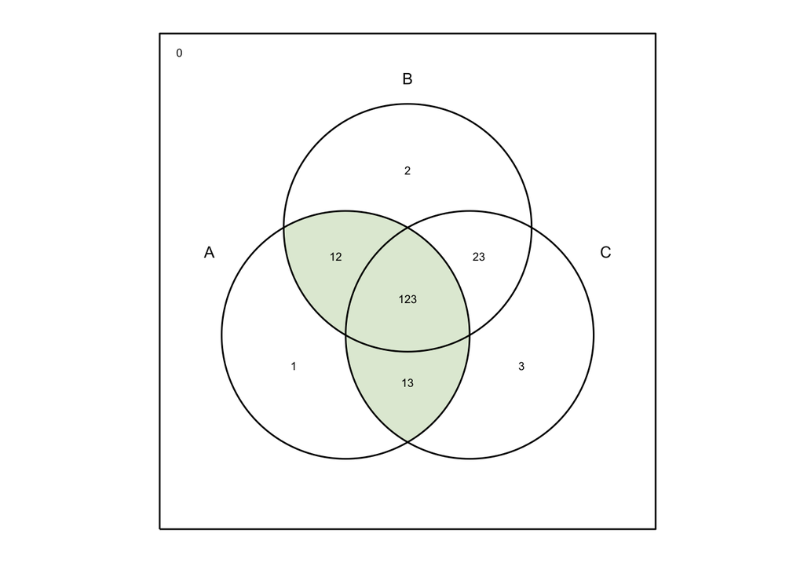

```r
library('venn')
library('grid')
library('gridGraphics')
venn("A~BC + AB~C + ABC", ilabels = TRUE, ggplot = TRUE)
```

1. A 6-letter “word” is formed by selecting 6 of the 26 letters without replacement. Two examples of such words are FRISBE and XEALRY. Let $A_{1}$ be the set of all words beginning with $X$ and $A_{2}$ be the set of all words ending with $Y$. Find the numbers of distinct words in:
   1. $A_{1} \cap A_{2}$

   $A_{1} = 1*25*24*23*22*21 = 6375600$

   $A_{1} \cap A_{2} = 1* 24* 23* 22* 21* 1 = 255024$

```r
1*25*24*23*22*21
```

```
## [1] 6375600
```

```r
1*24*23*22*21*1
```

```
## [1] 255024
```

1. $A_{1} \cup A_{2}$

$A_{1} \cup A_{2} = A_{1} + A_{2} - A_{1} \cap A_{2}$

$6375600 + 6375600 - 255024 = 12496176$

1. How many bit strings of length 8 either start with a 1 bit or end with the two bits 00?

   $1*2^{7} = 128$ $2^{6}*1*1 = 64$ $2^{5}*1*1*1 = 32$
2. Two cards are drawn without replacement from a standard deck of playing cards. Draw a Venn diagram that relates the following four events: $A$: Both cards are from the same suit; $B$: Both cards have the same rank; $C$: One card is a face card and the other card is a number card; $D:$ Both cards are from a red suit.
3. Consider the Venn diagram with three sets $A, B$, and $C$ shown below.

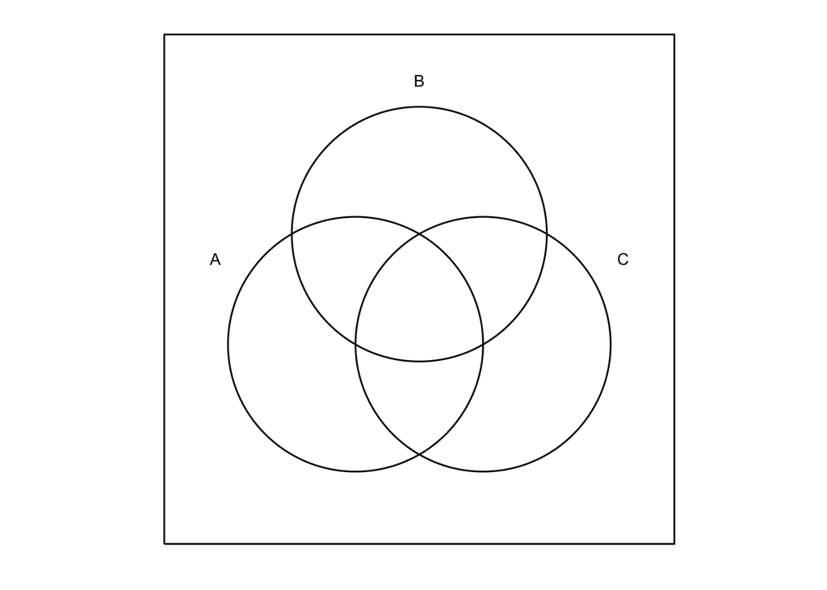

   ```r
   library("venn")
   library("ggplot2")
   library("ggpolypath")
   # venn(3, ggplot=TRUE, ilabels=TRUE, zcolor="style")
   venn(3, ggplot=TRUE)
   ```

   1. How many ways are there to shade various regions of the Venn diagram? For example, shading the entirety of $A$ is one way to shade the Venn diagram; shading just the portion of $A$ that does not intersect $B$ or $C$ is a second way to shade the Venn diagram. Assume that not shading any region does not count as shading.

```r
choose(8,1)+choose(8,2)+choose(8,3)+choose(8,4)+choose(8,5)+choose(8,6)+choose(8,7)+choose(8,8)
```

```
## [1] 255
```

1. Find the number of ways to shade regions of the Venn diagram associated with sets that can be written in the form:

{set 1} {operator 1} ({ set 2} [operator 2}{set 3}),

where $\{$set 1$\}$ is either $A$ or $A^{\prime},\{$set 2$\}$ is either $B$ or $B^{\prime},\{$set 3$\}$ is either $C$ or $C^{\prime}$, {operator 1} is either $\cap$ or $\cup$, and {operator 2} is either $\cap$ or $\cup$. An example of such a set is $A^{\prime} \cap\left(B \cup C^{\prime}\right)$.

$2^{5} = 32$